# Understanding probability

# Understanding probability

Let’s roll a die… Questo è un commento all’esercizio.

```r
# questo è un commento
sample(x = 1:6, size = 5, replace = FALSE)
```

```
## [1] 2 5 4 1 3
```

```r
sample(x = 1:6, size = 20, replace = TRUE)
```

```
##  [1] 6 4 3 6 5 5 1 3 5 2 5 5 2 5 6 1 1 3 3 6
```

```r
sample(x = 1:6, size = 20, replace = TRUE) # you get different numbers
```

```
##  [1] 5 1 3 2 1 5 1 2 2 6 5 2 4 5 6 5 4 6 4 2
```

```r
sample(x = 1:6, size = 20, replace = TRUE) # again
```

```
##  [1] 6 5 3 5 6 4 6 5 2 4 2 1 4 5 3 4 4 2 3 3
```

How often do you get a 6?

```r
RollDie <- function(n) sample(1:6, n, replace = TRUE)
d1 <- RollDie(n = 50)
sum(d1 == 6)
```

```
## [1] 8
```

```r
sum(d1 == 6)/50
```

```
## [1] 0.16
```

We can plot a relative histogram using:

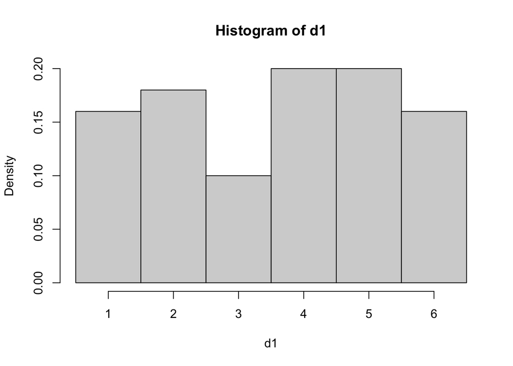

```r
hist(d1, probability = TRUE, breaks = seq(0.5,6.5,1))
```

Let’s simulate 500 rolls:

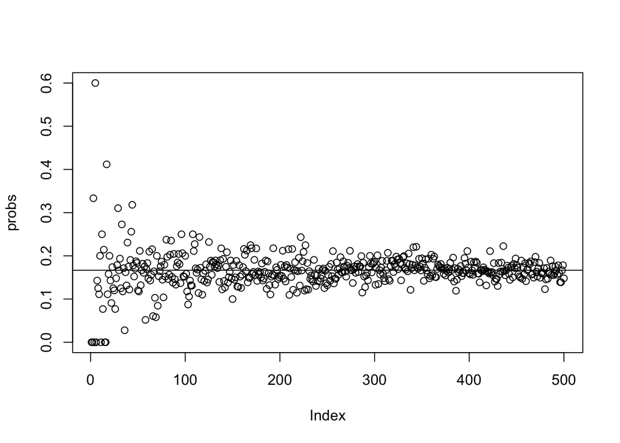

```r
sims <- vector("list", 500)
probs <- vector("numeric", 500)
for (n in 1:500) {
  sims[[n]] <- RollDie(n)
  probs[n] <- sum(sims[[n]] == 6)/n
}
plot(probs)
abline(h=1/6)
```

Please remember that our definition of probability is ‘long-run relative frequency’.  
If we repeat an experiment (like flipping a coin or rolling a dice) a large number of times and tabulate the outcomes, the relative frequencies will ‘converge’ to the probabilities of each outcome.  
This is the basic principles of Monte Carlo Simulations - Monte Carlo Simulation means using a computer to repeatedly carry out a random experiment and keeping track of the outcomes. That’s what we just did!! (http://ditraglia.com/Econ103Public/Rtutorials/Rtutorial4.html#introduction)

The probability of obtaining a 6 is a **marginal probability**. “The interesting thing about a marginal probability is that the term sounds complicated, but it’s actually the probability that we are most familiar with. Basically anytime you are in interested in a single event irrespective of any other event (i.e. “marginalizing the other event”), then it is a marginal probability. For instance, the probability of a coin flip giving a head is considered a marginal probability because we aren’t considering any other events.” (http://tinyheero.github.io/2016/03/20/basic-prob.html)  
E.g. what is the probability of capturing an adult snow vole?

Now we can roll two dice:

```r
sample(1:6, size = 1, replace = TRUE)
```

```
## [1] 3
```

```r
sample(1:6, size = 1, replace = TRUE)
```

```
## [1] 6
```

How often do we get the same number if we roll 2 dice?

```r
roll1 = NULL  #This initializes our variable - i.e. it creates a spot in memory for it. We need to do this for any vector, table, matrix, dataframe, but not for single numbers
roll2 = NULL
for (i in 1:100) {
    roll1[i] = RollDie(1)
    roll2[i] = RollDie(1)
}
# We can ask how many doubles we came up with:
sum(roll1 == roll2)
```

```
## [1] 17
```

```r
# relative frequency
sum(roll1 == roll2)/100
```

```
## [1] 0.17
```

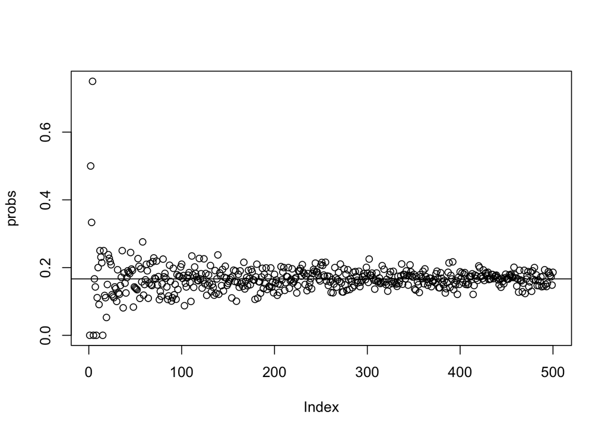

```r
roll1 <- vector("list", 500)
roll2 <- vector("list", 500)
probs <- vector("numeric", 500)
for (n in 1:500) {
  roll1[[n]] <- RollDie(n)
  roll2[[n]] <- RollDie(n)
  probs[n] <- sum(roll1[[n]] == roll2[[n]])/n
}
plot(probs)
abline(h=1/6)
```

Now we can ask for the sum of the two rolls:

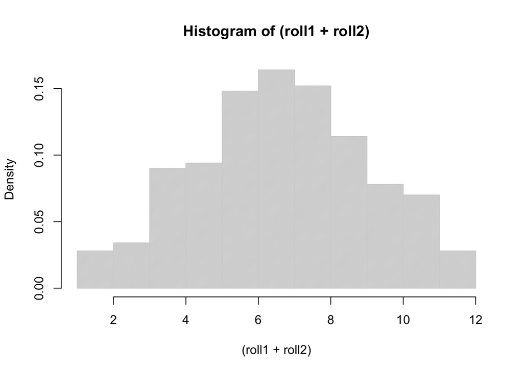

```r
n = 500
roll1 = NULL  #This initializes our variable - i.e. it creates a spot in memory for it. We need to do this for any vector, table, matrix, dataframe, but not for single numbers
roll2 = NULL
for (i in 1:n) {
    roll1[i] = RollDie(1)
    roll2[i] = RollDie(1)
}
hist((roll1 + roll2), density = 100, breaks = 1:12, prob = T)
```

[figure not shown]

```r
barplot(table(roll1 + roll2), main = "2 Dice Sum, 100 Rolls")  #this works better for this case
```

```r
rolls <- roll1 + roll2
sum(rolls == 7)
```

```
## [1] 82
```

```r
sum(rolls == 7)/n
```

```
## [1] 0.164
```

# Joint probability

**Joint probability**: probability of the joint occurrence of two independent events. *i.e.*, the probability of two different events occurring at the same time. Il two events (A and B) are **independent**, then P(A and B) = P(A) * P(B).

Again, we roll 2 dice.  
How often do we get a 6 in both rolls?

```r
n = 1500
roll1 = NULL  #This initializes our variable - i.e. it creates a spot in memory for it. We need to do this for any vector, table, matrix, dataframe, but not for single numbers
roll2 = NULL
for (i in 1:n) {
    roll1[i] = RollDie(1)
    roll2[i] = RollDie(1)
}
# We can ask how many times this happen:
sum(roll1 == 6 & roll2 == 6)
```

```
## [1] 48
```

```r
# the relative frequency is:
sum(roll1 == 6 & roll2 == 6)/n
```

```
## [1] 0.032
```

Repeat the previous code, changing n (50, 100, 200, 500). Find the relative frequencies.

Compare with:

```r
(1/6)*(1/6)
```

```
## [1] 0.02777778
```

E.g. you caught a snow vole: what is the probability that it is an adult and that it is female? The joint probability can be calculated by taking the proportion of times a specific combination of age and sex occurs, divided by the total number of age-sex classes combinations (but see below for this specific example - joint distribution of conditionally dependent variables).

# Mutually exclusive events

When you roll a die, you can roll a 5 OR a 6 (the odds are 1 out of 6 for each event) and the sum of either event happening is the sum of both probabilities:  
P(rolling a 5 or rolling a 6) = P(rolling a 5) + P(rolling a 6)  
P(rolling a 5 or rolling a 6) = 1/6 + 1/6 = 2/6 = 1/3.

Think about the previous example of rolling 2 dice. We asked how many times we got the same number from them:  
P(rolling a 1 and rolling a 1) = 1/6 * 1/6 = 0.02777778  
P(rolling a 2 and rolling a 2) = 1/6 * 1/6 = 0.02777778  
P(rolling a 3 and rolling a 3) = 1/6 * 1/6 = 0.02777778  
P(rolling a 4 and rolling a 4) = 1/6 * 1/6 = 0.02777778  
P(rolling a 5 and rolling a 5) = 1/6 * 1/6 = 0.02777778  
P(rolling a 6 and rolling a 6) = 1/6 * 1/6 = 0.02777778

These events are mutually exclusive, we can not get 1 in both rolls and 2 in both rolls. Try to sum up these probabilities:

```r
0.02777778+0.02777778+0.02777778+0.02777778+0.02777778+0.02777778
```

```
## [1] 0.1666667
```

```r
# or
0.02777778*6
```

```
## [1] 0.1666667
```

# Conditional probability

A conditional probability is the probability of an event X occurring when a secondary event Y is true. Mathematically, it is represented as P(X | Y). This is read as “probability of X given/conditioned on Y”.

# Think about biological data…

http://tinyheero.github.io/2016/03/20/basic-prob.html

What is the probability of capturing an adult snow vole? (marginal)  
What is the probability of capturing a female snow vole? (marginal)  
What is the probability of capturing a female adult snow vole? (joint)  
What is the probability of capturing a female, given that it is an adult? (conditional)

```r
y <- read.csv("data/captures.csv",sep=";")
y <- na.omit(y[,c("age", "sex")])
```

The marginal probability of capturing an adult snow vole is:

```r
library(dplyr)
age.marginal.df <-
  y %>%
  group_by(age) %>%
  summarise(n = n()) %>%
  ungroup() %>%
  mutate(prop = n/sum(n))
age.marginal.df
```

| age | n | prop |
| --- | --- | --- |
| A | 79 | 0.8494624 |
| G | 14 | 0.1505376 |

And the probability of capturing a female snow vole is:

```r
sex.marginal.df <-
  y %>%
  group_by(sex) %>%
  summarise(n = n()) %>%
  ungroup() %>%
  mutate(prop = n/sum(n))
sex.marginal.df
```

| sex | n | prop |
| --- | --- | --- |
| F | 33 | 0.3548387 |
| M | 60 | 0.6451613 |

Joint probabilities can be calculated by taking the proportion of times a specific sex-age combination occurs, divided by total number of all sex-age combinations (i.e. frequency):

```r
joint.df <-
  y %>%
  group_by(age, sex) %>%
  summarise(n = n()) %>%
  ungroup() %>%
  mutate(prop = n/sum(n))
```

[output not shown]

```r
joint.df
```

| age | sex | n | prop |
| --- | --- | --- | --- |
| A | F | 32 | 0.34408602 |
| A | M | 47 | 0.50537634 |
| G | F | 1 | 0.01075269 |
| G | M | 13 | 0.13978495 |

What is the probability of capturing a female, given that it is an adult? (conditional)

```r
joint.prob <-
  joint.df %>%
  filter(age == "A", sex == "F") %>%
  .$prop
joint.prob
```

```
## [1] 0.344086
```

```r
marg.prob <-
  age.marginal.df %>%
  filter(age == "A") %>%
  .$prop
marg.prob
```

```
## [1] 0.8494624
```

```r
cond.prob <- joint.prob/marg.prob
cond.prob
```

```
## [1] 0.4050633
```

i.e. 32 adult females out of a total of 79 adults.

Please note that if variables are not conditionally independent, their joint distribution is not equal to P(A)*P(B), but rather by P(B)*P(A | B). Check this by multiplying the conditional probability obtained here by the marginal probability of being an adult (B). Compare with the joint.df table.